# Common Garden Design

## Intro

Determine randomization strategy and plant placing when we have had uneven germination of our original plan.

This is written for UCD Fall 2022 planting.

```r
library(tidyverse)
library(googlesheets4)
library(ggforce)

is.even <- function(x) x%%2 == 0
```

## get data on germinated seed

```r
# the original reps
seed <- read_sheet("https://docs.google.com/spreadsheets/d/1EaSA2QrlWAjFR35pedcvheQp3X7Agsla6pZtE2C1QJ4/edit#gid=1798047255",
                   sheet = "germination",
                   na=c("NA", "")
) %>%
  select(parent.pop, mf, rep, `germinated?`)
```

```
✔ Reading from Pops_for_2022_UCD.
✔ Range ''germination''.
```

```r
seed
```

| parent.pop | mf | rep | germinated? |
| --- | --- | --- | --- |
| BH | 1 | 1 | 0 |
| BH | 1 | 2 | 0 |
| BH | 1 | 3 | 0 |
| BH | 1 | 4 | 0 |
| BH | 1 | 5 | 0 |
| BH | 1 | 6 | 0 |
| BH | 1 | 7 | 1 |
| BH | 1 | 8 | 1 |
| BH | 1 | 9 | 0 |
| BH | 1 | 10 | 1 |

[output cut: 990 more lines]

```r
# extra seed
extra <- read_sheet("https://docs.google.com/spreadsheets/d/1EaSA2QrlWAjFR35pedcvheQp3X7Agsla6pZtE2C1QJ4/edit#gid=1798047255",
                   sheet = "extra mf reps",
                   na=c("NA", "")
) %>%
  filter(`germinated?` == 1) # we are not going to use ungerminated extra seed.
```

```
✔ Reading from Pops_for_2022_UCD.
✔ Range ''extra mf reps''.
```

```r
extra
```

| parent.pop | mf | rep | germinated? |
| --- | --- | --- | --- |
| BH | 7 | 14 | 1 |
| BH | 7 | 15 | 1 |
| BH | 7 | 16 | 1 |
| BH | 7 | 17 | 1 |
| BH | 7 | 18 | 1 |
| BH | 7 | 19 | 1 |
| BH | 7 | 20 | 1 |
| BH | 7 | 21 | 1 |
| BH | 7 | 22 | 1 |
| BH | 7 | 23 | 1 |

[output cut: 120 more lines]

```r
seed.combined <- bind_rows(seed, extra)

germinated <- seed.combined %>%
  filter(`germinated?`==1)

notgerminated <- seed.combined %>%
  filter(`germinated?` == 0)
```

## assign blocks to germinated

Can plant 160 plants per bed

```r
nrow(germinated)
```

```
[1] 757
```

```r
nrow(germinated) / 160
```

```
[1] 4.73125
```

get a histogram of rep count

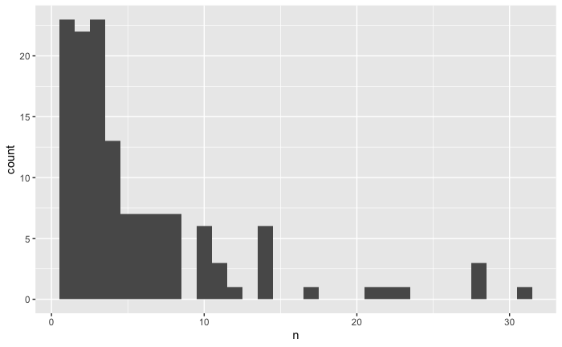

```r
germinated %>%
  group_by(parent.pop, mf) %>%
  summarize(n=n()) %>%
  ggplot(aes(x=n)) +
  geom_histogram(binwidth = 1)
```

```r
germinated %>%
  group_by(parent.pop) %>%
  summarize(n=n()) %>%
  arrange(n)
```

| parent.pop | n |
| --- | --- |
| WV | 2 |
| LV1 | 3 |
| YO4 | 6 |
| CP3 | 8 |
| WR | 9 |
| SQ3 | 10 |
| YO8 | 13 |
| YO11 | 14 |
| LVTR1 | 15 |
| YO7 | 17 |

[output cut: 13 more lines]

A bit challenging because for pops with few reps total we should be careful to distribute the pops across the blocks.

I think one way this can work is to arrange by pops and mfs and then assign a randomized set of block labels to it.

```r
# Remember, Bed A is buffer

germbeds <- c("D", "F", "H", "J", "L")
notgermbeds <- LETTERS[2:14] %>% setdiff(germbeds)

germblocks <- str_c(rep(germbeds,2), c("1", "2")) %>% sort

germreps <- ceiling(nrow(germinated) / 10 ) # number of times we have to assign blocks

# set.seed(777)
# germinated <- germinated %>%
#   arrange(parent.pop, mf) %>%
#   mutate(block= {map(1:germreps, ~ sample(germblocks)) %>%
#       unlist() %>% magrittr::extract(1:nrow(germinated))}, # clean up last rep
#       bed=str_sub(block, 1,1)
#       )


germinated$block <- rep(germblocks, length.out=nrow(germinated))
#for low rep mfs, randomize the whole pop
set.seed(777)
germinated_lowrep <- germinated %>%
  group_by(parent.pop, mf) %>%
  mutate(reps=n()) %>%
  filter(reps < 10) %>%
  group_by(parent.pop) %>%
  mutate(block= {map(1:ceiling(n()/10), ~ sample(germblocks)) %>%
       unlist() %>% magrittr::extract(1:n())}, # clean up last rep
         bed=str_sub(block, 1,1)) %>%
  ungroup()

#For high rep mfs, just use the sequentially assigned blocks
germinated_highrep <- germinated %>%
  group_by(parent.pop, mf) %>%
  mutate(reps=n()) %>%
  filter(reps >= 10) %>%
  ungroup %>%
  mutate(bed=str_sub(block, 1,1))

germinated <- bind_rows(germinated_lowrep, germinated_highrep) %>% arrange(parent.pop, mf)


# set.seed(777)
# germinated <- germinated %>%
#   arrange(parent.pop, mf) %>%
#   mutate(block= rep(germblocks, length.out = 757)) %>%
#   group_by(parent.pop) %>%
#   mutate(block=sample(block), #sampling within pop
#          bed=str_sub(block, 1,1)) %>%
#   ungroup()


germinated
```

| parent.pop | mf | rep | germinated? | block | reps | bed |
| --- | --- | --- | --- | --- | --- | --- |
| BH | 1 | 7 | 1 | J2 | 3 | J |
| BH | 1 | 8 | 1 | D1 | 3 | D |
| BH | 1 | 10 | 1 | D2 | 3 | D |
| BH | 2 | 1 | 1 | F2 | 14 | F |
| BH | 2 | 2 | 1 | H1 | 14 | H |
| BH | 2 | 3 | 1 | H2 | 14 | H |
| BH | 2 | 4 | 1 | J1 | 14 | J |
| BH | 2 | 5 | 1 | J2 | 14 | J |
| BH | 2 | 6 | 1 | L1 | 14 | L |
| BH | 2 | 7 | 1 | L2 | 14 | L |

[output cut: 747 more lines]

reality check distribution across mfs

```r
germinated %>%
  pivot_wider(id_cols = c(parent.pop, mf), names_from = block, values_from = `germinated?`, values_fill = 0, values_fn = sum)
```

| parent.pop | mf | J2 | D1 | D2 | F2 | H1 | H2 | J1 | L1 | L2 | F1 |
| --- | --- | --- | --- | --- | --- | --- | --- | --- | --- | --- | --- |
| BH | 1 | 1 | 1 | 1 | 0 | 0 | 0 | 0 | 0 | 0 | 0 |
| BH | 2 | 1 | 1 | 1 | 2 | 2 | 2 | 1 | 2 | 1 | 1 |
| BH | 3 | 2 | 1 | 1 | 1 | 1 | 1 | 2 | 2 | 2 | 1 |
| BH | 4 | 2 | 2 | 2 | 1 | 1 | 1 | 1 | 1 | 2 | 1 |
| BH | 5 | 3 | 3 | 3 | 4 | 4 | 3 | 3 | 2 | 2 | 4 |
| BH | 6 | 1 | 1 | 1 | 1 | 1 | 2 | 2 | 1 | 1 | 1 |
| BH | 7 | 3 | 2 | 2 | 2 | 2 | 2 | 2 | 3 | 3 | 2 |
| CC | 1 | 0 | 0 | 1 | 1 | 0 | 0 | 0 | 1 | 1 | 0 |
| CC | 2 | 1 | 1 | 1 | 0 | 1 | 1 | 1 | 0 | 1 | 1 |
| CC | 3 | 1 | 1 | 0 | 1 | 1 | 1 | 1 | 1 | 0 | 1 |

[output cut: 123 more lines]

reality check distribution across parent.pops

```r
germinated %>%
  pivot_wider(id_cols = parent.pop, names_from = block, values_from = `germinated?`, values_fill = 0, values_fn = sum)
```

| parent.pop | J2 | D1 | D2 | F2 | H1 | H2 | J1 | L1 | L2 | F1 |
| --- | --- | --- | --- | --- | --- | --- | --- | --- | --- | --- |
| BH | 13 | 11 | 11 | 11 | 11 | 11 | 11 | 11 | 11 | 10 |
| CC | 4 | 5 | 4 | 5 | 5 | 4 | 4 | 5 | 4 | 4 |
| CP2 | 3 | 4 | 4 | 4 | 4 | 4 | 4 | 4 | 4 | 3 |
| CP3 | 1 | 0 | 1 | 1 | 1 | 1 | 1 | 1 | 0 | 1 |
| DPR | 2 | 2 | 2 | 3 | 2 | 2 | 2 | 3 | 2 | 2 |
| FR | 4 | 4 | 4 | 4 | 3 | 4 | 3 | 4 | 4 | 4 |
| IH | 4 | 6 | 7 | 5 | 4 | 4 | 5 | 4 | 5 | 5 |
| LV1 | 0 | 0 | 0 | 0 | 1 | 0 | 0 | 0 | 1 | 1 |
| LV3 | 7 | 5 | 7 | 7 | 6 | 8 | 7 | 6 | 6 | 6 |
| LVTR1 | 1 | 2 | 2 | 1 | 1 | 1 | 2 | 1 | 2 | 2 |

[output cut: 13 more lines]

plants per block:

```r
germinated %>%
  group_by(block) %>%
  summarise(n=n())
```

| block | n |
| --- | --- |
| D1 | 76 |
| D2 | 80 |
| F1 | 75 |
| F2 | 76 |
| H1 | 70 |
| H2 | 74 |
| J1 | 75 |
| J2 | 75 |
| L1 | 79 |
| L2 | 77 |

## assign blocks to nongerminated

We aren’t using buffer rows, so can plant 176 plants per bed

```r
nrow(notgerminated)
```

```
[1] 1414
```

```r
nrow(notgerminated) / 176
```

```
[1] 8.034091
```

```r
nrow(notgerminated) %% 176
```

```
[1] 6
```

So, use 8 beds. Six seeds won’t make it into this design.

get a histogram of rep count

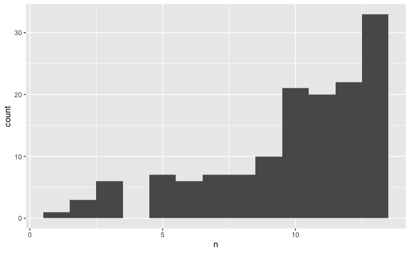

```r
notgerminated %>%
  group_by(parent.pop, mf) %>%
  summarize(n=n()) %>%
  ggplot(aes(x=n)) +
  geom_histogram(binwidth = 1)
```

```r
notgerminated %>%
  group_by(parent.pop) %>%
  summarize(n=n()) %>%
  arrange(n)
```

| parent.pop | n |
| --- | --- |
| BH | 11 |
| WL1 | 16 |
| WR | 30 |
| LV3 | 34 |
| CC | 47 |
| IH | 52 |
| SQ1 | 53 |
| TM2 | 54 |
| FR | 55 |
| SC | 55 |

[output cut: 13 more lines]

remove the six seed from mfs with 13 reps

```r
remove <- notgerminated %>%
  group_by(parent.pop, mf) %>%
  mutate(reps=n()) %>%
  ungroup() %>%
  filter(reps==13, rep==13) %>% # use pops that have the highest number mfs in this category
  group_by(parent.pop) %>%
  mutate(mfs=n()) %>%
  arrange(desc(mfs)) %>%
  filter(row_number(mf)==sample(row_number(mf), size = 1)) %>% # pick a random mf for each pop
  ungroup() %>%
  slice_max(mfs, n=6, with_ties = FALSE) %>% # 6 pops with largest number of mfs with 13 non germinated
select(-reps, -mfs)

notgerminated <- notgerminated %>% anti_join(remove)
dim(notgerminated)
```

```
[1] 1408    4
```

```r
set.seed(777)
notgermblocks <- str_c(rep(notgermbeds,each=2), c("1", "2")) %>% sample

notgermreps <- ceiling(nrow(notgerminated) / length(notgermblocks) ) # number of times we have to assign blocks

# I'm going to be a little more simplistic about the randomization for the non germinated since we can't cope with unequal block size

notgerminated$block <- rep(notgermblocks, length.out=nrow(notgerminated))
#for low rep mfs, randomize the whole pop
set.seed(777)
notgerminated_lowrep <- notgerminated %>%
  group_by(parent.pop, mf) %>%
  mutate(reps=n()) %>%
  filter(reps < 8) %>%
  group_by(parent.pop) %>%
  mutate(block= sample(block),
         bed=str_sub(block, 1,1)) %>%
  ungroup()

#For high rep mfs, just use the sequentially assigned blocks
notgerminated_highrep <- notgerminated %>%
  group_by(parent.pop, mf) %>%
  mutate(reps=n()) %>%
  filter(reps >= 8) %>%
  ungroup %>%
  mutate(bed=str_sub(block, 1,1))

notgerminated <- bind_rows(notgerminated_lowrep, notgerminated_highrep) %>% arrange(parent.pop, mf)

notgerminated
```

| parent.pop | mf | rep | germinated? | block | reps | bed |
| --- | --- | --- | --- | --- | --- | --- |
| BH | 1 | 1 | 0 | G2 | 10 | G |
| BH | 1 | 2 | 0 | B1 | 10 | B |
| BH | 1 | 3 | 0 | I2 | 10 | I |
| BH | 1 | 4 | 0 | K2 | 10 | K |
| BH | 1 | 5 | 0 | C1 | 10 | C |
| BH | 1 | 6 | 0 | M2 | 10 | M |
| BH | 1 | 9 | 0 | I1 | 10 | I |
| BH | 1 | 11 | 0 | K1 | 10 | K |
| BH | 1 | 12 | 0 | N2 | 10 | N |
| BH | 1 | 13 | 0 | C2 | 10 | C |

[output cut: 990 more lines]

reality check distribution across mfs

```r
notgerminated %>%
  mutate(notgerminated=1) %>%
  pivot_wider(id_cols = c(parent.pop, mf), names_from = block, values_from = notgerminated, values_fill = 0, values_fn = sum) %>%
  relocate(sort(notgermblocks), .after=mf)
```

| parent.pop | mf | B1 | B2 | C1 | C2 | E1 | E2 | G1 | G2 | I1 | I2 | K1 | K2 | M1 | M2 | N1 | N2 |
| --- | --- | --- | --- | --- | --- | --- | --- | --- | --- | --- | --- | --- | --- | --- | --- | --- | --- |
| BH | 1 | 1 | 0 | 1 | 1 | 0 | 0 | 0 | 1 | 1 | 1 | 1 | 1 | 0 | 1 | 0 | 1 |
| BH | 6 | 0 | 0 | 0 | 0 | 0 | 0 | 1 | 0 | 0 | 0 | 0 | 0 | 0 | 0 | 0 | 0 |
| CC | 1 | 1 | 1 | 0 | 0 | 1 | 1 | 0 | 1 | 0 | 1 | 0 | 1 | 1 | 0 | 1 | 0 |
| CC | 2 | 0 | 0 | 1 | 0 | 1 | 1 | 0 | 0 | 1 | 0 | 1 | 0 | 0 | 0 | 0 | 0 |
| CC | 3 | 0 | 0 | 0 | 0 | 0 | 0 | 0 | 0 | 0 | 1 | 1 | 1 | 1 | 0 | 0 | 1 |
| CC | 4 | 0 | 0 | 1 | 1 | 0 | 0 | 1 | 0 | 0 | 0 | 0 | 0 | 0 | 1 | 0 | 1 |
| CC | 5 | 1 | 1 | 0 | 1 | 0 | 0 | 0 | 1 | 1 | 0 | 0 | 0 | 0 | 1 | 1 | 0 |
| CC | 6 | 1 | 1 | 0 | 0 | 1 | 1 | 1 | 1 | 0 | 0 | 0 | 0 | 1 | 0 | 1 | 0 |
| CC | 7 | 0 | 0 | 1 | 1 | 0 | 0 | 0 | 0 | 1 | 1 | 1 | 1 | 0 | 1 | 0 | 1 |
| CP2 | 1 | 1 | 1 | 0 | 0 | 1 | 1 | 1 | 1 | 0 | 1 | 0 | 1 | 1 | 0 | 1 | 0 |

[output cut: 133 more lines]

reality check distribution across parent.pops

```r
notgerminated %>%
    mutate(notgerminated=1) %>%
  pivot_wider(id_cols = parent.pop, names_from = block, values_from = notgerminated, values_fill = 0, values_fn = sum) %>%
    relocate(sort(notgermblocks), .after=parent.pop)
```

| parent.pop | B1 | B2 | C1 | C2 | E1 | E2 | G1 | G2 | I1 | I2 | K1 | K2 | M1 | M2 | N1 | N2 |
| --- | --- | --- | --- | --- | --- | --- | --- | --- | --- | --- | --- | --- | --- | --- | --- | --- |
| BH | 1 | 0 | 1 | 1 | 0 | 0 | 1 | 1 | 1 | 1 | 1 | 1 | 0 | 1 | 0 | 1 |
| CC | 3 | 3 | 3 | 3 | 3 | 3 | 2 | 3 | 3 | 3 | 3 | 3 | 3 | 3 | 3 | 3 |
| CP2 | 4 | 4 | 4 | 4 | 4 | 4 | 5 | 4 | 4 | 4 | 4 | 4 | 4 | 4 | 4 | 4 |
| CP3 | 5 | 6 | 5 | 5 | 6 | 6 | 5 | 5 | 5 | 5 | 5 | 5 | 6 | 5 | 6 | 5 |
| DPR | 5 | 4 | 5 | 4 | 4 | 4 | 4 | 5 | 4 | 5 | 4 | 5 | 4 | 4 | 4 | 4 |
| FR | 3 | 4 | 3 | 4 | 3 | 3 | 4 | 3 | 4 | 3 | 4 | 3 | 3 | 4 | 3 | 4 |
| IH | 3 | 3 | 3 | 3 | 4 | 4 | 3 | 3 | 3 | 3 | 3 | 3 | 4 | 3 | 4 | 3 |
| LV1 | 6 | 5 | 6 | 5 | 5 | 5 | 5 | 6 | 6 | 6 | 5 | 6 | 5 | 6 | 5 | 5 |
| LV3 | 2 | 2 | 2 | 2 | 2 | 2 | 2 | 2 | 2 | 2 | 3 | 2 | 2 | 2 | 2 | 3 |
| LVTR1 | 5 | 5 | 5 | 5 | 5 | 5 | 5 | 5 | 4 | 5 | 4 | 5 | 5 | 4 | 5 | 4 |

[output cut: 13 more lines]

plants per block:

```r
notgerminated %>%
  group_by(block) %>%
  summarise(n=n())
```

| block | n |
| --- | --- |
| B1 | 88 |
| B2 | 88 |
| C1 | 88 |
| C2 | 88 |
| E1 | 88 |
| E2 | 88 |
| G1 | 88 |
| G2 | 88 |
| I1 | 88 |
| I2 | 88 |

[output cut: 6 more lines]

plants per bed

```r
notgerminated %>%
  group_by(bed) %>%
  summarise(n=n())
```

| bed | n |
| --- | --- |
| B | 176 |
| C | 176 |
| E | 176 |
| G | 176 |
| I | 176 |
| K | 176 |
| M | 176 |
| N | 176 |

Looks good

## planting grid

60 inch veg crops bed is 100 cm of plantable width.

Create grid

```r
stagger <- TRUE
buffer.beds <- 2
buffer.rows <- 2 # on each edge of each bed
exp.beds <- 13
beds <- LETTERS[1:(buffer.beds+exp.beds)]
columns <- 4 # per bed
rows <- 44 # four of which are buffers
plants <- length(beds) * columns * rows
bedwidth <- 100 # cm
furrow <- 52 #cm
size <- 30 # plant diameter
radius <- size/2
blankevery <- 2 # what is the spacing between blank beds?  (2 means every other; 3 means every third)
expandfactor <- blankevery/(blankevery-1)

plan3 <- expand_grid(bed=beds,
                     column=1:columns,
                     row=1:rows,
                     radius=radius)

plan3 <- plan3 %>%
  mutate(plantedcol=(match(bed, LETTERS)-1)*4 + column,
         bedcol = floor((match(bed, LETTERS)-1)*expandfactor + 1   ))

plan3
```

| bed | column | row | radius | plantedcol | bedcol |
| --- | --- | --- | --- | --- | --- |
| A | 1 | 1 | 15 | 1 | 1 |
| A | 1 | 2 | 15 | 1 | 1 |
| A | 1 | 3 | 15 | 1 | 1 |
| A | 1 | 4 | 15 | 1 | 1 |
| A | 1 | 5 | 15 | 1 | 1 |
| A | 1 | 6 | 15 | 1 | 1 |
| A | 1 | 7 | 15 | 1 | 1 |
| A | 1 | 8 | 15 | 1 | 1 |
| A | 1 | 9 | 15 | 1 | 1 |
| A | 1 | 10 | 15 | 1 | 1 |

[output cut: 990 more lines]

add positions

```r
if (stagger) {
  ## first part needs to be updated for beds
  column_offset <- sqrt((2*radius)^2 - radius^2) # Pythagorean theorem for offset spacing
  plan3 <- plan3 %>%
    mutate(y_pos=ifelse(is.even(column),
                        row*size,
                        row*size-radius),
           x_pos=ifelse(column==1,
                        radius+(bedcol-1)*(bedwidth+furrow),
                        radius+(column-1)*column_offset+(bedcol-1)*(bedwidth+furrow)))
} else {
  plan3 <- plan3 %>%
    mutate(y_pos=row*size,
           x_pos=bedcol*(bedwidth+furrow))
}
plan3
```

| bed | column | row | radius | plantedcol | bedcol | y_pos | x_pos |
| --- | --- | --- | --- | --- | --- | --- | --- |
| A | 1 | 1 | 15 | 1 | 1 | 15 | 15.00000 |
| A | 1 | 2 | 15 | 1 | 1 | 45 | 15.00000 |
| A | 1 | 3 | 15 | 1 | 1 | 75 | 15.00000 |
| A | 1 | 4 | 15 | 1 | 1 | 105 | 15.00000 |
| A | 1 | 5 | 15 | 1 | 1 | 135 | 15.00000 |
| A | 1 | 6 | 15 | 1 | 1 | 165 | 15.00000 |
| A | 1 | 7 | 15 | 1 | 1 | 195 | 15.00000 |
| A | 1 | 8 | 15 | 1 | 1 | 225 | 15.00000 |
| A | 1 | 9 | 15 | 1 | 1 | 255 | 15.00000 |
| A | 1 | 10 | 15 | 1 | 1 | 285 | 15.00000 |

[output cut: 990 more lines]

Plot it

```r
#create bed labels
# bed.labels <- plan3 %>%
#   group_by(bed) %>%
#   summarize(x_pos = mean(x_pos+bed_x_offset), y_pos=max(y_pos*1.075))


plan3 %>% #filter(bed=="A", row <6) %>%
  ggplot(aes(x0=x_pos, y0=y_pos, r=radius)) +
  geom_circle(fill="lightgreen", alpha=.25) +
  coord_equal() +
  #  geom_text(aes(x=x_pos, y=y_pos, label=bed), size= 14, data = bed.labels, inherit.aes = FALSE) +
  theme(axis.text = element_text(size=18), axis.title = element_text(size=18)) +
  xlab("position (cm)") + ylab("position (cm)")

ggsave("../output/FieldPlan.jpeg", width = 10, height = 6)
```

[output not shown]

Plot it in feet

```r
#create bed labels
# bed.labels <- plan3 %>%
#   group_by(bed) %>%
#   summarize(x_pos = mean(x_pos+bed_x_offset), y_pos=max(y_pos*1.075))


plan3 %>% #filter(bed=="A", row <6) %>%
  mutate(across(.cols=c(x_pos, y_pos, radius), ~ .x*0.0328084)) %>% # convert cm to feet
  ggplot(aes(x0=x_pos, y0=y_pos, r=radius)) +
  geom_circle(fill="lightgreen", alpha=.25) +
  coord_equal(xlim = c(4,145)) +
  #  geom_text(aes(x=x_pos, y=y_pos, label=bed), size= 14, data = bed.labels, inherit.aes = FALSE) +
  theme(axis.text = element_text(size=18), axis.title = element_text(size=18)) +
  xlab("position (feet)") + ylab("position (feet)")

# ggsave("../output/FieldPlan.jpeg", width = 10, height = 6)
```

[output not shown]

Output spacing for Black A to use as guide for cuting holes

```r
x_labels <- plan3 %>% filter(bed=="A") %>% pull(x_pos) %>% round(1) %>% unique()

plan3 %>% filter(bed=="A") %>%
  ggplot(aes(x0=x_pos, y0=y_pos, r=radius, label=y_pos)) +
  geom_circle(fill="lightgreen", alpha=.25, color="grey70") +
  geom_text(aes(x=x_pos, y=y_pos), size=3) +
  scale_x_continuous(breaks = x_labels) +
  coord_equal(ylim = c(20,660)) +
  #  geom_text(aes(x=x_pos, y=y_pos, label=bed), size= 14, data = bed.labels, inherit.aes = FALSE) +
  theme(axis.text.x = element_text(angle=90, size=12, vjust = 0.5)) +
  xlab("position (cm)") + ylab("position (cm)")
ggsave("../output/spacing_guide_1.pdf", width = 8, height = 10.5)

plan3 %>% filter(bed=="A") %>%
  ggplot(aes(x0=x_pos, y0=y_pos, r=radius, label=y_pos)) +
  geom_circle(fill="lightgreen", alpha=.25, color="grey70") +
  geom_text(aes(x=x_pos, y=y_pos), size=3) +
  scale_x_continuous(breaks = x_labels) +
  coord_equal(ylim = c(700,1320)) +
  #  geom_text(aes(x=x_pos, y=y_pos, label=bed), size= 14, data = bed.labels, inherit.aes = FALSE) +
  theme(axis.text.x = element_text(angle=90, size=12, vjust = 0.5)) +
  xlab("position (cm)") + ylab("position (cm)")
ggsave("../output/spacing_guide_2.pdf", width = 8, height = 10.5)
```

## Assign Plants

### germinated

```r
set.seed(999)
germinated <- germinated %>%
  group_by(bed) %>%
  arrange(block) %>%
  mutate(row=rep(3:(2+ceiling(n()/columns)), each=columns, length.out=n())) %>%
  group_by(block) %>%
  mutate(row=ifelse(str_sub(block,2,2) == "2" & (length(row[row==min(row)]) < columns), row+1, row)) %>%
  mutate(row=sample(row)) %>%
  group_by(bed, row) %>%
  mutate(column=sample(LETTERS[1:columns], size=n())) %>%
  select(-reps)

germinated  %>% arrange(block, row)
```

| parent.pop | mf | rep | germinated? | block | bed | row | column |
| --- | --- | --- | --- | --- | --- | --- | --- |
| CP2 | 10 | 4 | 1 | D1 | D | 3 | B |
| IH | 2 | 13 | 1 | D1 | D | 3 | D |
| LV3 | 1 | 6 | 1 | D1 | D | 3 | C |
| WL2 | 4 | 11 | 1 | D1 | D | 3 | A |
| CC | 4 | 9 | 1 | D1 | D | 4 | C |
| CC | 5 | 12 | 1 | D1 | D | 4 | B |
| YO11 | 4 | 10 | 1 | D1 | D | 4 | A |
| YO7 | 8 | 1 | 1 | D1 | D | 4 | D |
| BH | 5 | 24 | 1 | D1 | D | 5 | B |
| FR | 1 | 12 | 1 | D1 | D | 5 | D |

[output cut: 747 more lines]

```r
germinated  %>% arrange(parent.pop, mf) # confirm different positions per block
```

| parent.pop | mf | rep | germinated? | block | bed | row | column |
| --- | --- | --- | --- | --- | --- | --- | --- |
| BH | 1 | 8 | 1 | D1 | D | 9 | C |
| BH | 1 | 10 | 1 | D2 | D | 30 | D |
| BH | 1 | 7 | 1 | J2 | J | 37 | B |
| BH | 2 | 8 | 1 | D1 | D | 19 | B |
| BH | 2 | 9 | 1 | D2 | D | 29 | D |
| BH | 2 | 10 | 1 | F1 | F | 17 | B |
| BH | 2 | 1 | 1 | F2 | F | 35 | D |
| BH | 2 | 11 | 1 | F2 | F | 33 | D |
| BH | 2 | 2 | 1 | H1 | H | 17 | C |
| BH | 2 | 12 | 1 | H1 | H | 4 | B |

[output cut: 747 more lines]

Fill in the blanks…

```r
germ.fill <- germinated %>%
  filter(str_detect(block, "1")) %>%
  group_by(block) %>%
  expand(row=1:max(row), column) %>%
  mutate(bed=str_sub(block, 1,1))

germ.fill <- germinated %>%
  filter(str_detect(block, "2")) %>%
  group_by(block) %>%
  expand(row=min(row):(max(row)+2), column) %>%
  bind_rows(germ.fill) %>%
  mutate(bed=str_sub(block, 1,1))

germinated <- germ.fill %>%
  left_join(germinated) %>%
  mutate(parent.pop=ifelse(is.na(parent.pop), "buffer", parent.pop))
         # ,
         # block=ifelse(!is.na(block), block,
         #              ifelse(row < 3, str_c(bed,"1"), str_c(bed, "2"))))

germinated
```

| block | row | column | bed | parent.pop | mf | rep | germinated? |
| --- | --- | --- | --- | --- | --- | --- | --- |
| D2 | 22 | A | D | CP2 | 9 | 2 | 1 |
| D2 | 22 | B | D | SQ1 | 4 | 4 | 1 |
| D2 | 22 | C | D | BH | 7 | 18 | 1 |
| D2 | 22 | D | D | LV3 | 7 | 13 | 1 |
| D2 | 23 | A | D | YO11 | 3 | 12 | 1 |
| D2 | 23 | B | D | CP2 | 10 | 3 | 1 |
| D2 | 23 | C | D | SQ3 | 4 | 11 | 1 |
| D2 | 23 | D | D | SQ2 | 6 | 3 | 1 |
| D2 | 24 | A | D | LVTR1 | 7 | 6 | 1 |
| D2 | 24 | B | D | IH | 6 | 6 | 1 |

[output cut: 846 more lines]

### assign positions for not germinated

```r
set.seed(999)
notgerminated <- notgerminated %>%
  group_by(bed) %>%
  arrange(block) %>%
  mutate(row=rep(1:rows, each=columns, length.out=n())) %>%
  group_by(block) %>%
  mutate(row=sample(row)) %>%
  group_by(bed, row) %>%
  mutate(column=sample(LETTERS[1:columns], size=n())) %>%
  select(-reps)

notgerminated  %>% arrange(block, row)
```

| parent.pop | mf | rep | germinated? | block | bed | row | column |
| --- | --- | --- | --- | --- | --- | --- | --- |
| LV1 | 4 | 13 | 0 | B1 | B | 1 | C |
| LVTR1 | 7 | 10 | 0 | B1 | B | 1 | A |
| YO11 | 3 | 7 | 0 | B1 | B | 1 | B |
| YO4 | 5 | 3 | 0 | B1 | B | 1 | D |
| DPR | 1 | 2 | 0 | B1 | B | 2 | B |
| YO11 | 4 | 13 | 0 | B1 | B | 2 | A |
| YO4 | 2 | 7 | 0 | B1 | B | 2 | D |
| YO4 | 7 | 10 | 0 | B1 | B | 2 | C |
| CP2 | 7 | 1 | 0 | B1 | B | 3 | C |
| FR | 4 | 10 | 0 | B1 | B | 3 | A |

[output cut: 990 more lines]

combine it

```r
plants <- bind_rows(germinated, notgerminated)
```

Write it out

```r
plants %>% arrange(parent.pop, mf, rep) %>%
  select(parent.pop, mf, rep, bed, block, row, column, everything() ) %>% write_sheet("https://docs.google.com/spreadsheets/d/1EaSA2QrlWAjFR35pedcvheQp3X7Agsla6pZtE2C1QJ4",
                                                        sheet="New Bed Map")
```

```
✔ Writing to Pops_for_2022_UCD.
✔ Writing to sheet New Bed Map.
```

### Correct positions for field mistakes / swaps

[output not shown]

## combine bed map and field map

```r
plan3_plants <- plan3 %>%
  mutate(column=LETTERS[column]) %>%
  full_join(plants) %>%
  mutate(label=ifelse(parent.pop=="buffer", "buff", str_c(parent.pop, "\n", mf, "-", rep) )) %>%
  mutate(label=ifelse(is.na(label), "buff", label)) %>%
  filter(!is.na(block))
pdf("../output/UCD2022_planting_maps.pdf",width = 8.5, height = 11)

for(b in unique(plan3_plants$block)) {
  germlabel <- ifelse(b %in% germblocks, " germinated", " NOT germinated")
  pl <- plan3_plants %>% filter(block==b) %>%
    ggplot(aes(x0=x_pos, y0=y_pos, r=radius, label=label)) +
    geom_circle(fill="lightgreen", alpha=.25, color="grey70") +
    geom_text(aes(x=x_pos, y=y_pos), size=3.5, lineheight=.8) +
    coord_equal() +
    theme(axis.text.x = element_text(angle=90, size=12, vjust = 0.5)) +
    xlab("position (cm)") + ylab("position (cm)") +
    scale_y_reverse() +
    ggtitle(str_c("Block ", b, germlabel))
  print(pl)
}

dev.off()
```

```r
pdf("../output/UCD2022_randomization_maps.pdf",width = 8.5, height = 11)
```

```r
for(b in unique(plan3_plants$block)) {
  germlabel <- ifelse(b %in% germblocks, " germinated", " NOT germinated")
  pl <- plan3_plants %>% filter(block==b) %>%
    ggplot(aes(x0=column, y0=row, label=label)) +
    geom_label(aes(x=column, y=row), size=3.5, lineheight=.8) +
    coord_equal() +
    theme(axis.text.x = element_text(angle=90, size=12, vjust = 0.5)) +
    scale_y_reverse(breaks = 1:44) +
    ggtitle(str_c("Block ", b, germlabel))
  print(pl)
}

dev.off()
```